# Aula 3: Álgebra matricial 3 e Análise dos Componentes Principais (*PCA*)

José Ricardo Inacio Ribeiro

Isso é um [R Markdown](http://rmarkdown.rstudio.com) Notebook depositado no [Bioforum](http://bioforum.wordpress.com). Quando executar o código, os resultados aparecerão abaixo dele!

## Vetores

```r
V1 <- as.vector(seq(1, 10))
V1
```

```
##  [1]  1  2  3  4  5  6  7  8  9 10
```

```r
V2 <- as.vector(seq(11, 20))
V2
```

```
##  [1] 11 12 13 14 15 16 17 18 19 20
```

### **_______exercício 7________:**

Existe outra forma de fazer isso?

```r
# Podemos adicionar uma constante a cada elemento:
V4 <- V1 + 20
V4
```

```
##  [1] 21 22 23 24 25 26 27 28 29 30
```

```r
# Ou podemos adicionar cada elemento do primeiro vetor ao elemento correspondente do segundo vetor
V3 <- V1 + V2
V3
```

```
##  [1] 12 14 16 18 20 22 24 26 28 30
```

```r
# Multiplicação de vetores por um escalar:
V2 <- 4 * V1
V2
```

```
##  [1]  4  8 12 16 20 24 28 32 36 40
```

```r
# Multiplicação de vetores onde cada elemento de um vetor é multiplicado pelo seu correspondente no outro vetor:
V1 * V2
```

```
##  [1]   4  16  36  64 100 144 196 256 324 400
```

```r
# Produto externo (lembre-se que o operador de multiplicação de matrizes é %*%):
V1 <- seq(1, 10)
V2 <- seq(1, 4)
V1
```

```
##  [1]  1  2  3  4  5  6  7  8  9 10
```

```r
V2
```

```
## [1] 1 2 3 4
```

```r
prod.ext <- V1 %*% t(V2) #temos que fazer a transposta
prod.ext
```

```
##       [,1] [,2] [,3] [,4]
##  [1,]    1    2    3    4
##  [2,]    2    4    6    8
##  [3,]    3    6    9   12
##  [4,]    4    8   12   16
##  [5,]    5   10   15   20
##  [6,]    6   12   18   24
##  [7,]    7   14   21   28
##  [8,]    8   16   24   32
##  [9,]    9   18   27   36
## [10,]   10   20   30   40
```

$\color{red}{\text{Temos que fazer a transposta porque $X_{n \times 1} \times Y_{1 \times m} = (XY)_{n \times m}$, segundo a figura abaixo:}}$

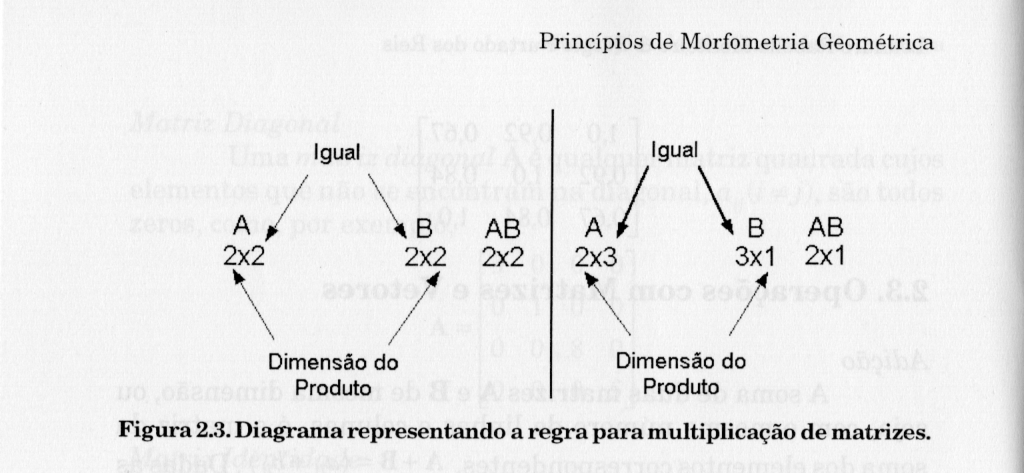

**O produto interno é uma operação muito útil, porque ele não só multiplica cada elemento correspondente de dois vetores mas também soma o produto resultante:**
$$produto-interno=\sum_{i=1}^{N} \mathbf{V1}_i \times \mathbf{V2}_i$$

```r
V1 <- seq(1, 10)
V2 <- seq(11, 20)
V1
```

```
##  [1]  1  2  3  4  5  6  7  8  9 10
```

```r
V2
```

```
##  [1] 11 12 13 14 15 16 17 18 19 20
```

```r
in.prod <- t(V1) %*% V2
in.prod #uma matriz de uma linha e uma coluna!
```

```
##      [,1]
## [1,]  935
```

Podemos normalizar vetores a partir do cálculo do produto-interno de um vetor. Norma de um vetor é seu *comprimento*. **Vamos calcular a raiz quadrada do seu produto-interno:**
$$||a|| = (\mathbf{a}^T \mathbf{a})^{1/2} = \sqrt{ \sum_{i=1}^{p}a^2_i}$$

```r
V1 <- seq(1, 10)
V1
```

```
##  [1]  1  2  3  4  5  6  7  8  9 10
```

```r
in.prod <- t(V1) %*% V1
in.prod #uma matriz de uma linha e uma coluna!
```

```
##      [,1]
## [1,]  385
```

```r
sqrt(in.prod)
```

```
##          [,1]
## [1,] 19.62142
```

```r
#vetor normalizado:
V1.n <- V1 / as.vector(sqrt(in.prod))
V1.n
```

```
##  [1] 0.05096472 0.10192944 0.15289416 0.20385888 0.25482360 0.30578831
##  [7] 0.35675303 0.40771775 0.45868247 0.50964719
```

### **_______exercício 8________:**

Qual o comprimento do vetor *V1.n?*

## Cálculo da variância usando vetores:

```r
V <- V1
V
```

```
##  [1]  1  2  3  4  5  6  7  8  9 10
```

```r
# Preciso calcular a média de todos os números em um vetor. Para tanto, (1) precisamos somar
# os números (com o produto-interno do vetor com um vetor de algarismos 1):
uns <- rep(1, length(V))
uns
```

```
##  [1] 1 1 1 1 1 1 1 1 1 1
```

```r
soma.V <- t(uns) %*% V
soma.V
```

```
##      [,1]
## [1,]   55
```

```r
# (2) Agora, dividimos pelo número de elementos de V:
media.V <- soma.V * (1/length(V))
media.V
```

```
##      [,1]
## [1,]  5.5
```

```r
# Colocando tudo junto:
media.V <- t(uns) %*% V * (1/length(V))
media.V
```

```
##      [,1]
## [1,]  5.5
```

```r
# ou:
mean(V)
```

```
## [1] 5.5
```

```r
# (3) A variância é o desvio-quadrado médio da média. Assim, (A) precisaremos achar
# os desvios da média subtraindo a média de cada valor do vetor:
V - as.vector(media.V)
```

```
##  [1] -4.5 -3.5 -2.5 -1.5 -0.5  0.5  1.5  2.5  3.5  4.5
```

```r
# (B) Então, achamos a variância como o quadrado médio a partir do produto-interno:
Var.V <- t(V - as.vector(media.V)) %*% (V - as.vector(media.V)) * (1/(length(V) - 1))
Var.V
```

```
##          [,1]
## [1,] 9.166667
```

```r
# ou:
var(V)
```

```
## [1] 9.166667
```

## Matrizes (combinção de vetores):

```r
Xc <- cbind(V1, V2, V3) #por colunas
Xc
```

```
##       V1 V2 V3
##  [1,]  1 11 12
##  [2,]  2 12 14
##  [3,]  3 13 16
##  [4,]  4 14 18
##  [5,]  5 15 20
##  [6,]  6 16 22
##  [7,]  7 17 24
##  [8,]  8 18 26
##  [9,]  9 19 28
## [10,] 10 20 30
```

```r
dim(Xc)
```

```
## [1] 10  3
```

```r
Xr <- rbind(V1, V2, V3) #por linhas
Xr
```

```
##    [,1] [,2] [,3] [,4] [,5] [,6] [,7] [,8] [,9] [,10]
## V1    1    2    3    4    5    6    7    8    9    10
## V2   11   12   13   14   15   16   17   18   19    20
## V3   12   14   16   18   20   22   24   26   28    30
```

```r
dim(Xr)
```

```
## [1]  3 10
```

Como em vetores, podemos somar, subtrair, multiplicar e dividir a matriz por um escalar: Dada a matriz
$$\mathbf{A} = \begin{bmatrix}
3 & 8 \\[0.3em]
10 & 4
\end{bmatrix}$$

Então, a operação 5**A**, onde o escalar é representado pelo número 5, é dada por…
$$5 \mathbf{A} = 5 \times \begin{bmatrix}
3 & 8 \\[0.3em]
10 & 4
\end{bmatrix} = \begin{bmatrix}
15 & 40 \\[0.3em]
50 & 20
\end{bmatrix}$$

É importante lembrar que, se a matriz tem um fator comum, esse fator pode ser extraído da matriz e tratado como um *escalar*…
$$\begin{bmatrix}
15 & 40 \\[0.3em]
50 & 20
\end{bmatrix} = 5 \begin{bmatrix}
3 & 8 \\[0.3em]
10 & 4
\end{bmatrix} =$$

Assim, se
$$\mathbf{A} = |a_{ij}|$$
e
$$\lambda$$
é um escalar, temos…
$$\lambda \mathbf{A} = \mathbf{A} \lambda = | \lambda a_{ij}|$$

#### Operações:

```r
Xc + 4 #adição
```

```
##       V1 V2 V3
##  [1,]  5 15 16
##  [2,]  6 16 18
##  [3,]  7 17 20
##  [4,]  8 18 22
##  [5,]  9 19 24
##  [6,] 10 20 26
##  [7,] 11 21 28
##  [8,] 12 22 30
##  [9,] 13 23 32
## [10,] 14 24 34
```

```r
round((Xc + 4) / 3, 2) #arredondando os valores
```

```
##         V1   V2    V3
##  [1,] 1.67 5.00  5.33
##  [2,] 2.00 5.33  6.00
##  [3,] 2.33 5.67  6.67
##  [4,] 2.67 6.00  7.33
##  [5,] 3.00 6.33  8.00
##  [6,] 3.33 6.67  8.67
##  [7,] 3.67 7.00  9.33
##  [8,] 4.00 7.33 10.00
##  [9,] 4.33 7.67 10.67
## [10,] 4.67 8.00 11.33
```

```r
# Nós podemos multiplicar cada linha (ou coluna) por um vetor!
V
```

```
##  [1]  1  2  3  4  5  6  7  8  9 10
```

```r
Xc * V
```

```
##        V1  V2  V3
##  [1,]   1  11  12
##  [2,]   4  24  28
##  [3,]   9  39  48
##  [4,]  16  56  72
##  [5,]  25  75 100
##  [6,]  36  96 132
##  [7,]  49 119 168
##  [8,]  64 144 208
##  [9,]  81 171 252
## [10,] 100 200 300
```

### Multiplicação de matrizes ($A \times B$):

$$xy_{ij} = \sum_{k=1}^{n}x_{ik} \times y_{jk}$$

```r
n <- dim(Xc)[1] # número de linhas
uns <- rep(1, n)
uns
```

```
##  [1] 1 1 1 1 1 1 1 1 1 1
```

```r
length(uns)
```

```
## [1] 10
```

```r
X.med <- t(uns) %*% Xc / n
X.med
```

```
##       V1   V2 V3
## [1,] 5.5 15.5 21
```

```r
#ou
colMeans(Xc)
```

```
##   V1   V2   V3
##  5.5 15.5 21.0
```

*Variâncias e covariâncias são medidas de dispersão ao redor da média!* Podemos calculá-las subtraindo as médias de todas as observações. Com isso, teremos uma **matriz centrada**. Usaremos o artifício da matriz de algarismos um…

```r
X.diff <- Xc - uns %*% X.med
X.diff #uma matriz centrada
```

```
##         V1   V2 V3
##  [1,] -4.5 -4.5 -9
##  [2,] -3.5 -3.5 -7
##  [3,] -2.5 -2.5 -5
##  [4,] -1.5 -1.5 -3
##  [5,] -0.5 -0.5 -1
##  [6,]  0.5  0.5  1
##  [7,]  1.5  1.5  3
##  [8,]  2.5  2.5  5
##  [9,]  3.5  3.5  7
## [10,]  4.5  4.5  9
```

Agora, calculamos o *produto-interno* da matriz centrada pelas médias com ela mesma! O resultado, dividiremos por $n - 1$.

### **_______exercício 9________:**

Como fazemos isso?

### A diagonal de uma matriz de variância-covariância contém a *variância*!

```r
X.cov <- t(X.diff) %*% X.diff
X.cov <- X.cov / (n - 1)
round(X.cov, 2)
```

```
##       V1    V2    V3
## V1  9.17  9.17 18.33
## V2  9.17  9.17 18.33
## V3 18.33 18.33 36.67
```

```r
dim(X.cov) #3x3
```

```
## [1] 3 3
```

```r
#ou simplesmente:
cov(Xc)
```

```
##           V1        V2       V3
## V1  9.166667  9.166667 18.33333
## V2  9.166667  9.166667 18.33333
## V3 18.333333 18.333333 36.66667
```

```r
diag(X.cov) #a diagonal é a variância
```

```
##        V1        V2        V3
##  9.166667  9.166667 36.666667
```

$\color{red}{\text{Portanto, podemos converter a matriz de variância-covariância em uma matriz de correlação!}}$ Lembre-se: $r_{xy} = cov_{xy} / \sqrt{\mathbf{V}_x \mathbf{V}_y}$

```r
# Multiplicaremos antes e depois a matriz pela diagonal contendo o recíproco
# dos desvios-padrão (a raiz quadrada das variâncias):
sdi <- diag(1 / sqrt(diag(X.cov))) #criamos uma matriz
sdi #desvios-padrão
```

```
##           [,1]      [,2]      [,3]
## [1,] 0.3302891 0.0000000 0.0000000
## [2,] 0.0000000 0.3302891 0.0000000
## [3,] 0.0000000 0.0000000 0.1651446
```

```r
dim(sdi) # 3x3
```

```
## [1] 3 3
```

```r
#3x3 X 3x3 X 3x3
X.cor <- sdi %*% X.cov %*% sdi
X.cor
```

```
##      [,1] [,2] [,3]
## [1,]    1    1    1
## [2,]    1    1    1
## [3,]    1    1    1
```

```r
#ou simplesmente:
cor(Xc)
```

```
##    V1 V2 V3
## V1  1  1  1
## V2  1  1  1
## V3  1  1  1
```

### Determinante de uma matriz quadrada:

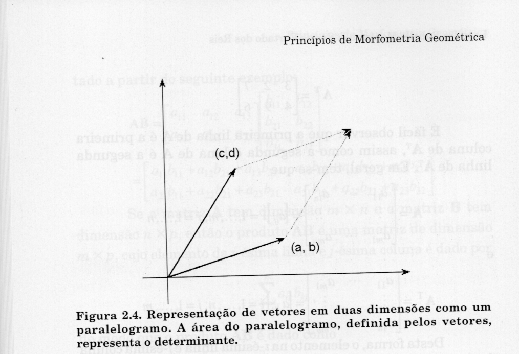

### $$\pm (ad - bc)$$

```r
A <- matrix(c(1, 2, 3, 4), byrow = T, nc = 2)
A
```

```
##      [,1] [,2]
## [1,]    1    2
## [2,]    3    4
```

```r
# O determinante, segundo a fórmula, será...
(A[1,1] * A[2,2]) - (A[1,2] * A[2,1]) # -2
```

```
## [1] -2
```

```r
#ou:
det(A) # -2
```

```
## [1] -2
```

### Vejamos o que acontece com o determinante de uma matriz em uma matriz que tenha suas colunas *linearmente dependentes*

```r
# uma matriz com colunas linearmente dependentes:
A <- matrix(c(1, 2, 2, 4), byrow = T, nc = 2)
A
```

```
##      [,1] [,2]
## [1,]    1    2
## [2,]    2    4
```

```r
dim(A)
```

```
## [1] 2 2
```

É fácil observar que a segunda coluna é um múltiplo da primeira. *A relação entre a primeira e segunda coluna pode ser escrita como…*
$$\begin{bmatrix}
2 \\[0.3em]
4
\end{bmatrix} = 2 \begin{bmatrix}
1 \\[0.3em]
2
\end{bmatrix} =$$

$\color{red}{\text{O conceito de posto de uma matriz está ligado intimamente à questão da dependência linear, porque o posto é o número máximo de}}$

$\color{red}{\text{colunas ou linhas linearmente INDEPENDENTES de uma matrix}}$

### **_______exercício 9________:**

Qual é o posto da matriz A?

O determinante de A será *zero*!

```r
det(A)
```

```
## [1] 0
```

$\color{red}{\text{Importante: quando uma matriz tem determinante igual a zero, dizemos que a matriz é SINGULAR!}}$

## Praticando PCA no R…

```r
#fazendo no geomorph:
library(geomorph)
tudo1 <- readland.tps(file = '~/Dropbox/aulas/Morfogeo/morfo_aulas/alunos_landmark/folhasok.TPS',
                      specID = 'ID')
```

```
##
## No curves detected; all points appear to be fixed landmarks.
##
## Warning: not all specimens have scale adjustment (perhaps because they are already scaled);
## no rescaling will be performed in these cases
```

```r
tudo1 #um array
```

```
## , , ori1
##
##       [,1] [,2]
##  [1,]  497 1068
##  [2,]  499 1146
##  [3,] 1121 1927
##  [4,] 1813 1760
##  [5,] 1980 1670
##  [6,] 2238 1545
##  [7,] 2423 1430
##  [8,] 2577 1319
##  [9,] 2980 1136
## [10,] 2631  941
## [11,] 2442  785
## [12,] 2245  657
```

[output cut: 288 more lines]

```r
?gpagen
#superimpose configurations
sup <- gpagen(A = tudo1, ProcD = T, Proj = T)
names(sup)
```

```
##  [1] "coords"       "Csize"        "iter"         "points.VCV"
##  [5] "points.var"   "consensus"    "procD"        "p"
##  [9] "k"            "nsliders"     "nsurf"        "data"
## [13] "Q"            "slide.method" "call"
```

```r
sup$coords #coordenadas sobrepostas
```

```
## , , ori1
##
##              X            Y
## 1  -0.41141968  0.003584539
## 2  -0.41016829  0.026467190
## 3  -0.21769177  0.250135576
## 4  -0.01564311  0.194983654
## 5   0.03292593  0.167000003
## 6   0.10739529  0.127992550
## 7   0.16075954  0.092448512
## 8   0.20498298  0.058390595
## 9   0.32084435  0.001126667
## 10  0.21712019 -0.052791254
## 11  0.16036732 -0.096743512
## 12  0.10127709 -0.132588336
```

[output cut: 288 more lines]

```r
# fazendo no shapes:
library(shapes)
tudo1 <- readland.tps(file = '~/Dropbox/aulas/Morfogeo/morfo_aulas/alunos_landmark/folhasok.TPS',
                      specID = 'ID')
```

```
##
## No curves detected; all points appear to be fixed landmarks.
##
## Warning: not all specimens have scale adjustment (perhaps because they are already scaled);
## no rescaling will be performed in these cases
```

```r
#configurações sobrepostas e projeção no espaço tangente
sup <- procGPA(tudo1)
tudo1 <- sup$tan # no espaço tangente
# guardando o tamanho do centroide
size<-sup$size

#PCA passo-a-passo
tudo1 <- scale(tudo1, center = TRUE, scale = FALSE)
p1 <- dim(tudo1)[2]
Nspec <- dim(tudo1)[1]
uns <- rep(1,dim(tudo1)[1])

#calculando a matriz de variância-covariância...
W <- t(tudo1) %*% tudo1 * (Nspec - 1)^-1 #para extrair autovetores X = ZLZ'
eigC <- eigen(W) #e1=t(e11,e12) é o primeiro autovetor dos escores quadrados do pooled
names(eigC)
```

```
## [1] "values"  "vectors"
```

```r
eigC$values #auto-valores
```

```
##  [1]  1.267973e+05  1.354813e+04  8.303790e+03  4.853308e+03  3.754453e+03
##  [6]  1.313037e+03  8.888490e+02  6.430521e+02  5.840912e+02  5.147342e+02
## [11]  3.144877e+02  1.788423e+02  1.053011e+02  6.059166e+01  2.366734e+01
## [16] -1.915443e-12
```

```r
eigC$vectors #auto-vetores
```

```
##             [,1]        [,2]         [,3]        [,4]         [,5]
##  [1,] -0.2642797  0.03524860  0.059481443 -0.13819086 -0.212581453
##  [2,] -0.3092028 -0.12443551 -0.179599262 -0.14071267  0.011800104
##  [3,] -0.1087306  0.63179160 -0.007951654  0.09210333 -0.078913679
##  [4,] -0.2041072  0.06196900  0.187267276  0.15211672 -0.101437050
##  [5,] -0.3168880 -0.35422439 -0.056500949  0.43850406  0.120754717
##  [6,] -0.2095867  0.11688816 -0.224568147 -0.36920443 -0.523326916
##  [7,] -0.2223204  0.05331072  0.434282287 -0.45523891  0.438718035
##  [8,] -0.3105691 -0.07231524 -0.135048123  0.26638854  0.360802249
##  [9,]  0.1946998 -0.32567920  0.403777865  0.09474530 -0.385790736
## [10,]  0.1579442 -0.08534677 -0.105895433  0.23105411 -0.214545388
## [11,]  0.2627383  0.40034663 -0.097638160  0.23783994  0.024981631
## [12,]  0.2711628 -0.02545723  0.469303082  0.12051720  0.007258509
## [13,]  0.2987191  0.07265782  0.081220336 -0.05258315  0.118804255
## [14,]  0.2207390 -0.03320564 -0.402939513  0.10345337  0.112784368
```

[output cut: 36 more lines]

```r
W.PCA <- tudo1 %*% eigC$vectors
W.PCA
```

```
##             [,1]        [,2]          [,3]        [,4]        [,5]
##  [1,] -783.94117   16.823824   12.58378424   36.244335    9.372707
##  [2,] -796.60912   35.258704   27.81629209   17.581360   15.628197
##  [3,]  271.63212 -222.446381 -137.45779163 -127.804896    2.294697
##  [4,]  277.27260   80.688553  277.56501592  -59.324032   61.275759
##  [5,]  303.59656   45.858580  172.45083908  -31.596270   30.844513
##  [6,]  153.11991  -32.310945   80.03167302   36.265335   48.518789
##  [7,]   33.61178  -49.866767  -16.51452591   88.902121   23.102288
##  [8,]  -91.43146  -82.107653   -7.45746342  110.960732  -21.495137
##  [9,] -538.86264    4.280545   24.35165663  101.771323  -21.206805
## [10,]  -29.08732  -48.230147   -4.87784418   47.445417 -124.862020
## [11,]   76.46383  -25.446107  -11.98949556    1.571524 -111.376129
## [12,]  191.31375   84.440587  -68.13366245  -75.481493 -121.568625
## [13,]  233.12139  207.991275 -111.42749874 -141.204750   -2.971743
## [14,]  268.41459  309.854116 -184.83733946   56.208364  108.469207
```

[output cut: 109 more lines]

### Quantidade de variância em cada eixo:

```r
#The proportion of the total sum of squares accounted for by the first principal component:
TSS <- 0
for (i in 1:dim(W.PCA)[2]){
  TSS[i] <- round((100 * eigC$values[i] / sum(eigC$values)), 4)
}
TSS # em porcentagem
```

```
##  [1] 78.3262  8.3691  5.1295  2.9980  2.3192  0.8111  0.5491  0.3972
##  [9]  0.3608  0.3180  0.1943  0.1105  0.0650  0.0374  0.0146  0.0000
```

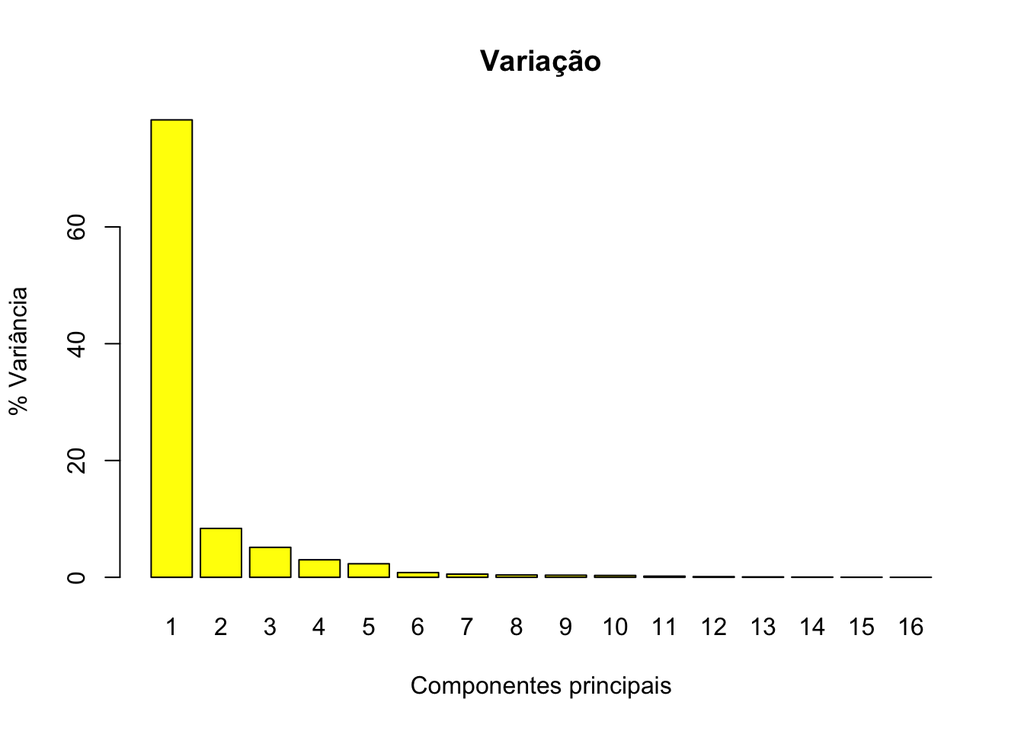

```r
#fazendo o histograma:
PCs <- c(seq(1:dim(W.PCA)[2]))
barplot(TSS[1:dim(W.PCA)[2]], names.arg = PCs, main = 'Variação', xlab = 'Componentes principais', ylab = '% Variância', col = 'yellow')
```

```r
# criando o fator tipo de folha
tudo1 <- readland.tps(file = '~/Dropbox/aulas/Morfogeo/morfo_aulas/alunos_landmark/folhasok.TPS',
                      specID = 'ID')
```

```
##
## No curves detected; all points appear to be fixed landmarks.
##
## Warning: not all specimens have scale adjustment (perhaps because they are already scaled);
## no rescaling will be performed in these cases
```

```r
tudo1 #um array
```

```
## , , ori1
##
##       [,1] [,2]
##  [1,]  497 1068
##  [2,]  499 1146
##  [3,] 1121 1927
##  [4,] 1813 1760
##  [5,] 1980 1670
##  [6,] 2238 1545
##  [7,] 2423 1430
##  [8,] 2577 1319
##  [9,] 2980 1136
## [10,] 2631  941
## [11,] 2442  785
## [12,] 2245  657
```

[output cut: 288 more lines]

```r
n <- dim(tudo1)[3] #número de indivíduos

#superimpose configurations
sup <- gpagen(A = tudo1, ProcD = T, Proj = T)
names(sup)
```

```
##  [1] "coords"       "Csize"        "iter"         "points.VCV"
##  [5] "points.var"   "consensus"    "procD"        "p"
##  [9] "k"            "nsliders"     "nsurf"        "data"
## [13] "Q"            "slide.method" "call"
```

```r
tudo1 <- sup$coords #coordenadas sobrepostas
dim(tudo1)
```

```
## [1] 15  2 16
```

```r
tudo1
```

```
## , , ori1
##
##              X            Y
## 1  -0.41141968  0.003584539
## 2  -0.41016829  0.026467190
## 3  -0.21769177  0.250135576
## 4  -0.01564311  0.194983654
## 5   0.03292593  0.167000003
## 6   0.10739529  0.127992550
## 7   0.16075954  0.092448512
## 8   0.20498298  0.058390595
## 9   0.32084435  0.001126667
## 10  0.21712019 -0.052791254
## 11  0.16036732 -0.096743512
## 12  0.10127709 -0.132588336
```

[output cut: 288 more lines]

```r
tipo <- c(rep("A", 8), rep("B", 8))
tipo <- as.factor(tipo)
tipo
```

```
##  [1] A A A A A A A A B B B B B B B B
## Levels: A B
```

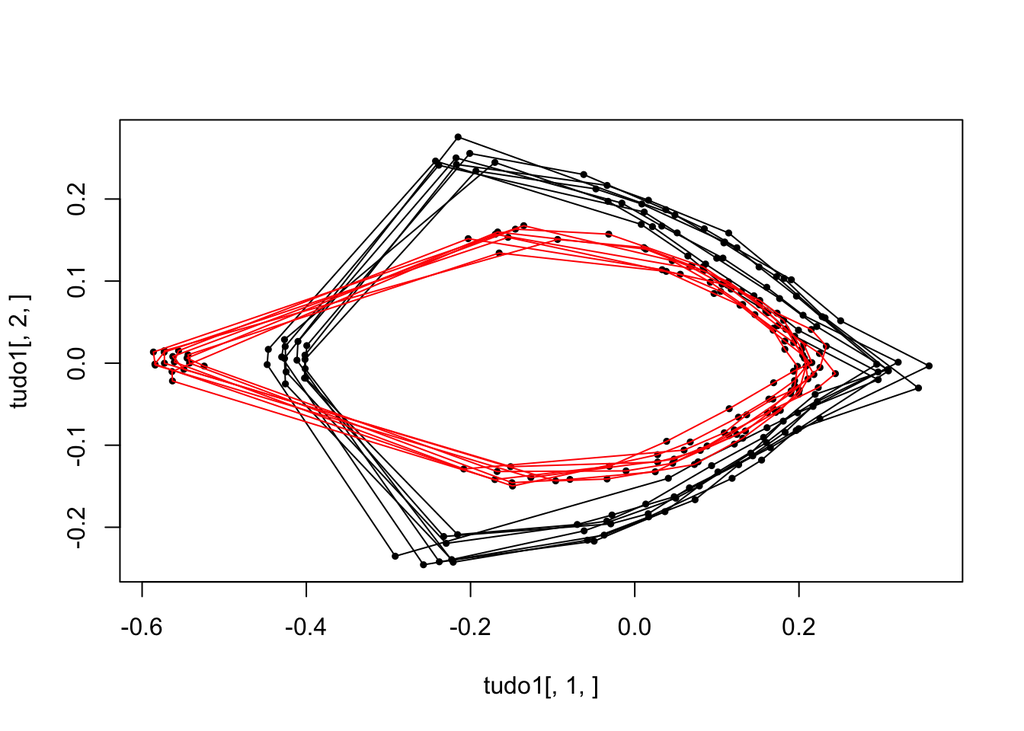

```r
#links between landmarks
link<-c(1 : 15, 1)

# Vamos representar as configurações superpostas com duas cores diferentes:
plot(tudo1[,1,], tudo1[,2,], asp = 1, bg = 1, pch = 21, cex = 0.5)
for (i in 1:n) {lines(tudo1[link,,i], col = (c(1, 2)[tipo])[i])}
```

### Explorando a variação morfológica nos dados usando a função “prcomp”:

```r
# Antes, temos que rearranjar os dados
M <- matrix(NA, n, 15 * 2)
for (i in 1:n){
  M[i,] <- tudo1[,,i]
  }
M #agora, temos os indivíduos nas linhas e os marcos nas colunas!
```

```
##             [,1]       [,2]        [,3]         [,4]        [,5]
##  [1,] -0.4114197 -0.4101683 -0.21769177 -0.015643109 0.032925932
##  [2,] -0.4014337 -0.3994430 -0.20093338 -0.062149921 0.037770367
##  [3,] -0.4476965 -0.4462779 -0.24263023  0.007855693 0.064665979
##  [4,] -0.4246162 -0.4257174 -0.23865949  0.011521293 0.051631245
##  [5,] -0.4008593 -0.4015873 -0.19343970 -0.047330713 0.008639234
##  [6,] -0.4300160 -0.4265948 -0.17032161 -0.032473236 0.021538855
##  [7,] -0.4255008 -0.4265385 -0.21518442  0.048916993 0.084743736
##  [8,] -0.4021706 -0.4016458 -0.21719529 -0.033684173 0.016696418
##  [9,] -0.5421939 -0.5441117 -0.16517670  0.038318837 0.112806178
## [10,] -0.5243981 -0.5452613 -0.16697203  0.013372688 0.067231780
## [11,] -0.5607601 -0.5556418 -0.20288043  0.033327417 0.096527347
## [12,] -0.5630512 -0.5636039 -0.16987770  0.083987382 0.129822043
## [13,] -0.5844367 -0.5731708 -0.15431669  0.055433976 0.104567127
## [14,] -0.5491557 -0.5626489 -0.14536324 -0.031722888 0.083235778
```

[output cut: 87 more lines]

```r
pca <- prcomp(M)
names(pca)
```

```
## [1] "sdev"     "rotation" "center"   "scale"    "x"
```

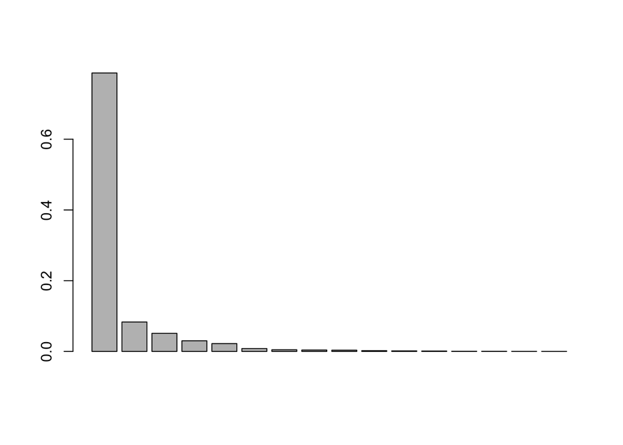

```r
# calculando-se a porcentagem de variância explicada pelos eixos:
barplot(pca$sdev^2 / sum(pca$sdev^2))
```

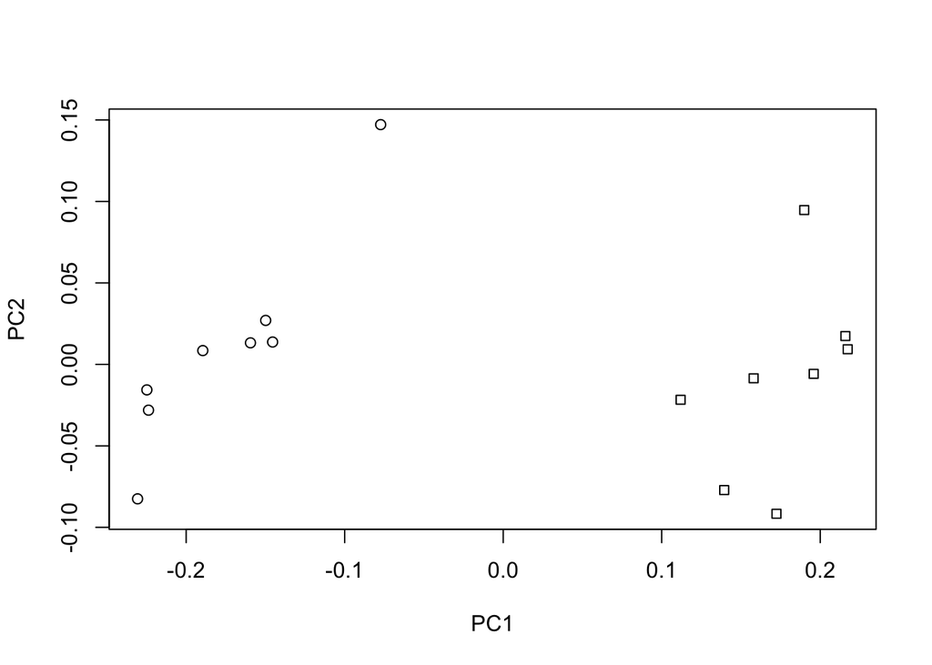

```r
# Vamos plotar os espécimes, com símbolos diferentes para
# os dois grupos de folhas
plot(pca$x[,1:2], pch=c(21,22)[tipo], xlab = "PC1", ylab = "PC2")
```

### Podemos usar esses valores ainda para algumas inferências estatísticas:

```r
# variância dos autovalores:
pca$sdev #autovalores
```

```
##  [1] 1.861223e-01 6.052338e-02 4.746342e-02 3.637415e-02 3.119541e-02
##  [6] 1.893293e-02 1.443687e-02 1.313641e-02 1.248057e-02 9.873369e-03
## [11] 8.324841e-03 6.894398e-03 4.497319e-03 3.973928e-03 1.956900e-03
## [16] 2.739914e-17
```

```r
t1 <- var(pca$sdev) #variância dos autovalores
t1
```

```
## [1] 0.002066424
```

```r
t2 <- sum(pca$sdev) #variância total
t2
```

```
## [1] 0.4561862
```

```r
TT <- t1 / t2 ^ 2 #variância escalonada dos autovalores
TT
```

```
## [1] 0.009929679
```

```r
mi <- (16 - 1) / (16 ^ 2) #máximo do índice escalonado
veig <- TT / mi
veig #variância na forma
```

```
## [1] 0.1694665
```